# tidyexposomics: integrated exposure-omics analysis powered by tidy principles

## Normality Check

When determining variable associations it is important to check the normality of the data. The `check_normality` function is used to check the normality of the data. The `transform_exposure` function is used to transform the data to make it more normal. Here the `transform_method` is set to `best` as it will compare the normality of the data before and after transformation and select the best method. The `transform_method` can be set to `log2`, `sqrt`, or `x_1_3`.

```r
# Check variable normality & transform variables
expom_qc <- expom_qc |>
  # Check variable normality
  run_normality_check(action = "add") |>

  # Transform variables
  transform_exposure(transform_method = "best",
                     cols_of_interest = exp_vars)
```

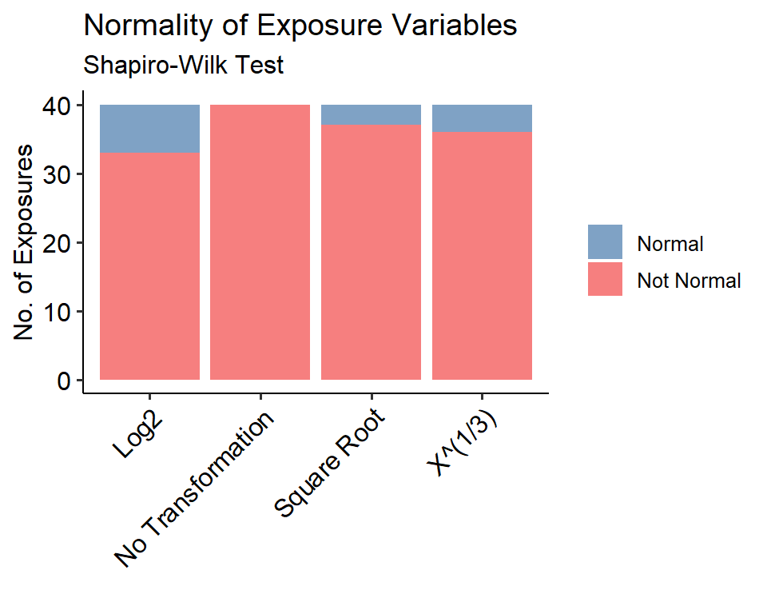

```r
expom_qc |>
  plot_normality_summary()
```

# Sample-Exposure Association

## Sample Clustering

```r
# Sample clustering
expom_sample_exp <- expom_qc |>
  run_cluster_samples(exposure_cols = exp_vars,
                  clustering_approach = "dynamic",
                  action = "add")
```

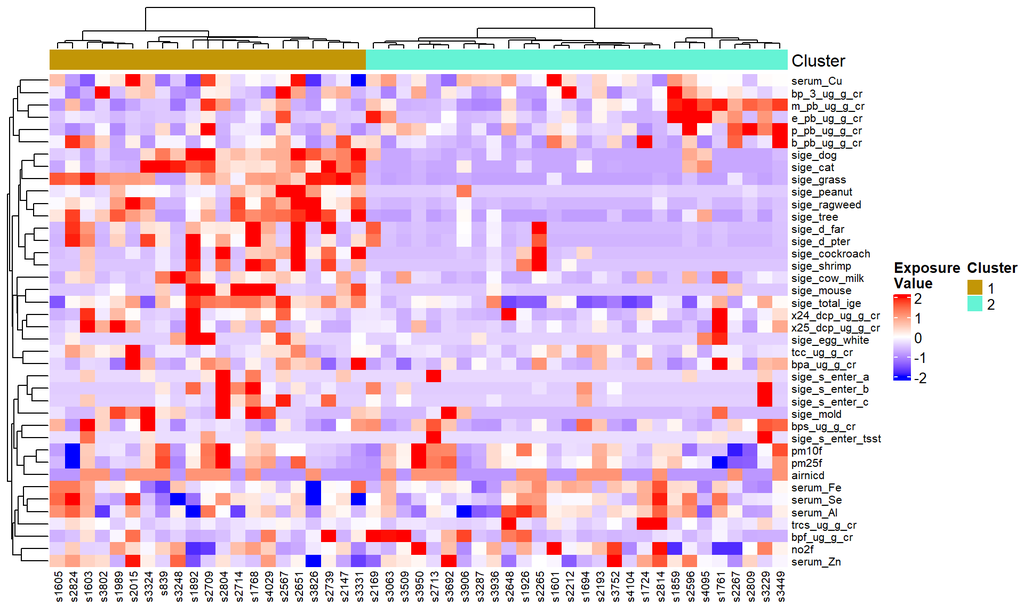

```r
# Plot sample clusters
expom_sample_exp |>
  plot_sample_clusters(cols_of_interest = exp_vars)
```

Here we see two clusters, largely driven by levels of Immunoglobulin E.

## ExWAS Association

```r
# Perform ExWAS Analysis
expom_sample_exp <- expom_sample_exp |>
  associate_exposure_outcome(
    outcome = "fev_height",
    exposures = all_vars[
      !all_vars %in% c("fev_height",
                       "age",
                       "sex",
                       "race")],
    covariates = c("age","sex","race"),
    action = "add")
```

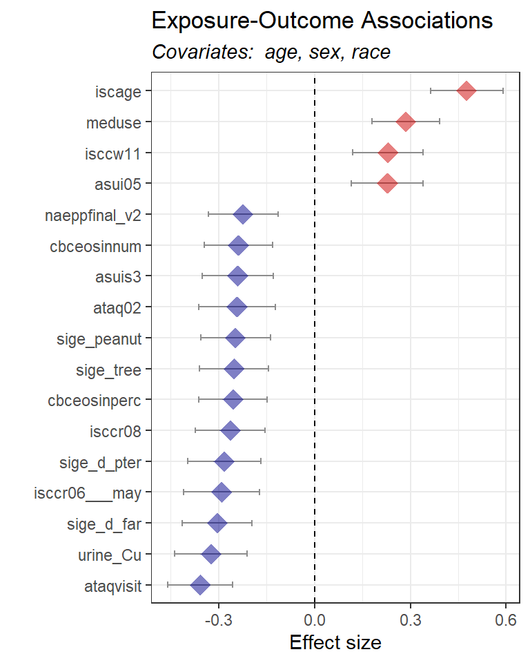

```r
expom_sample_exp |>
  plot_associate_exposure_outcome()
```

Here we see that urinary copper and eosinophil levels are associated with FEV1/height^2 after adjusting for age, sex, and race.

# Differential Abundance

## Differential Abundance

We also provide functionality to test for differentially abundant features associated with a particular outcome across several omics layers. Using a volcano plot, we can visualize the results of the differential abundance analysis.

```r
# Run differential abundance analysis
expom_da <- expom_sample_exp |>
  run_differential_abundance(
    formula = ~ fev_height + age + sex + race,
    method = "limma_voom",
    contrasts = c("fev_height - (Intercept)"),
    minimum_counts = 1,
    minimum_proportion = 0.1,
    scaling_method = "none",
    action = "add")
```

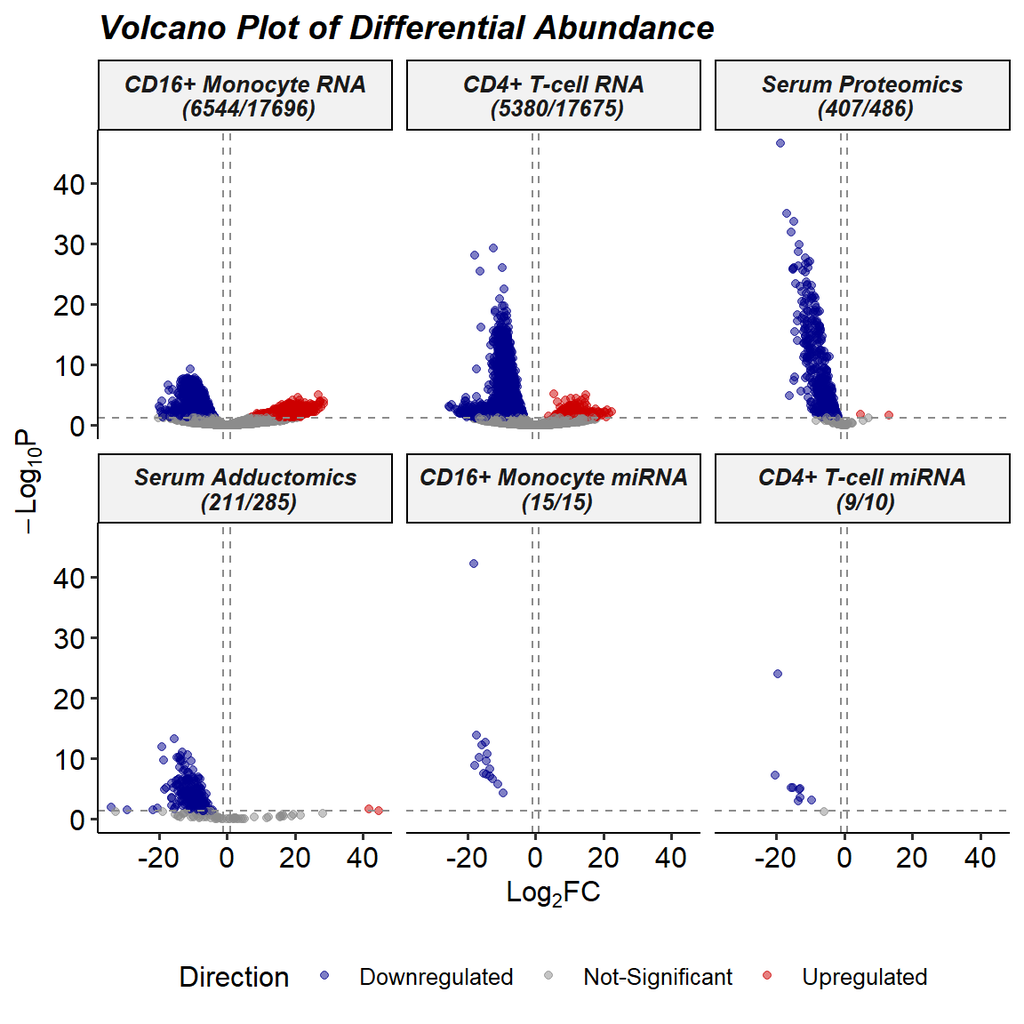

```r
# Plot Differential Abundance Results
expom_da |>
  plot_volcano(
    logFC_thresh = log2(2),
    pval_thresh = 0.05)
```

We note that CD16+ monocyte RNA has the greatest number of differentially abundant features, followed byCD4+ T-cell RNA, serum proteomics, serum adductomics, then CD16+ monocyte miRNA, CD4+ T-cell miRNA.

## Sensitivity Analysis

Depending on pre-processing steps, the results of the differential abundance analysis may vary. The `sensitivity_analysis` function is used to perform a sensitivity analysis to determine the robustness of the results. Here we determine if a feature is still differentially abundant if different minimum values, proportions, scaling methods are used, and the inclusion of covariates.

```r
# Perform Sensitivity Analysis
expom_da <- expom_da |>
  run_sensitivity_analysis(
    base_formula = ~ fev_height + age + sex + race,
    contrasts = c("fev_height - (Intercept)"),
    methods = c("limma_voom"),
    scaling_methods = c("none"),
    min_counts_range = c(1,5),
    min_proportion_range = c(0.1,0.3),
    covariates_to_remove = c("age" , "sex" , "race"),
    action = "add")
```

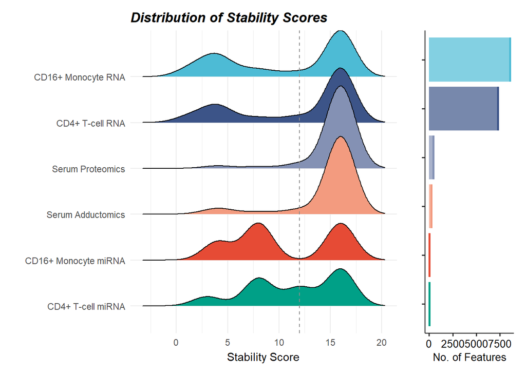

```r
# Plot sensitivity analysis results
expom_da |>
  plot_sensitivity_summary(stability_score_thresh = 12)
```

# Multi-Omics Integration

## Multi-Omics Integration

While differential abundance analysis per omic can deliver insights into how each omic is associated with a particular outcome, we may want to leverage methods which integrate multiple omics layers. The `run_multiomics_integration` function is used to integrate multiple omics layers. Here we use the `MCIA` method to integrate omics layers. We can then use `plot_factor_summary()` to visualize which omics contribute most to which factors.

```r
# Perform Multi-Omics Integration
expom_multi <- expom_da |>
  run_multiomics_integration(method = "MCIA",
                             action = "add")
```

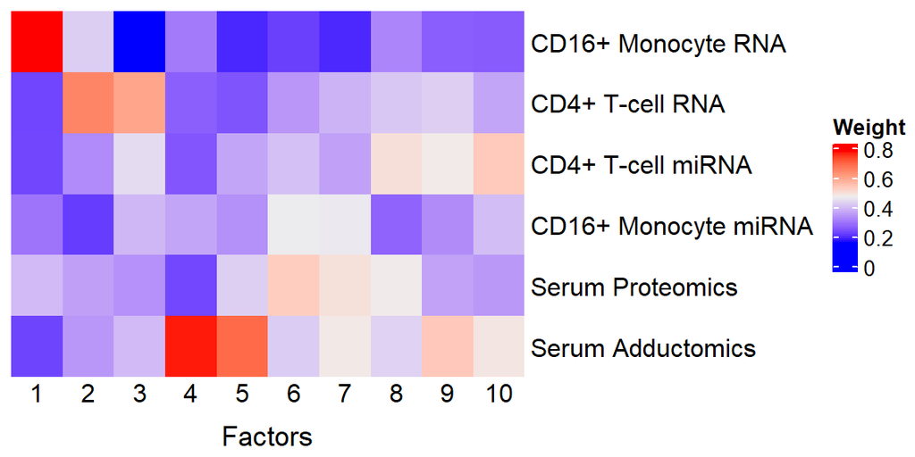

```r
# Plot multi-omics factor summary
expom_multi |>
  plot_factor_summary()
```

## Factor Analysis

```r
# Identify factors that correlate with the outcome
expom_multi <- expom_multi |>
  associate_factor_outcome(outcome_var = "fev_height",
                            categorical = FALSE,
                            p_thresh = 1,
                           action = "add")
```

```r
# Extract top features that contribute to a factor
expom_multi <- expom_multi |>
  extract_top_factor_features(factors = "V6",
                              method = "percentile",
                              percentile = 0.95,
                              threshold = 0.3,
                              action = "add")
```

# Exposure-Omics Association

## Exposure-Omics Association

Now we have the option to correlate either the top factor features, or differentially abundant features with exposures. Here we will correlate the top differentially abundant features with exposures.

```r
# Correlate top differentially abundant features with exposures
expom_multi <- expom_multi |>
  correlate_exposures_degs(exposure_cols = exp_vars,
                                robust = TRUE,
                                score_thresh = 12,
                           action = "add")
```

We can plot the results of the exposure-omics association analysis using the `plot_bar_correlate_summary` function.

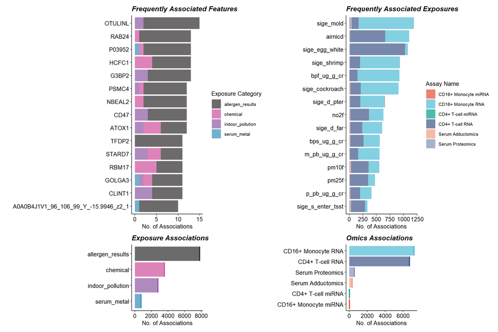

```r
expom_multi |>
  plot_bar_correlate_summary()
```

Here we note that transcriptomic features have a greater number of associations with exposures. Among exposures, we see that allergens have the greatest number of associations with features - although we note that there are more allergen variables than other exposure categories. So we include the number of features associated with each the top exposure, and the number of exposures associated with the top features. It may also be useful to identify which exposures are correlated with similar molecular features.

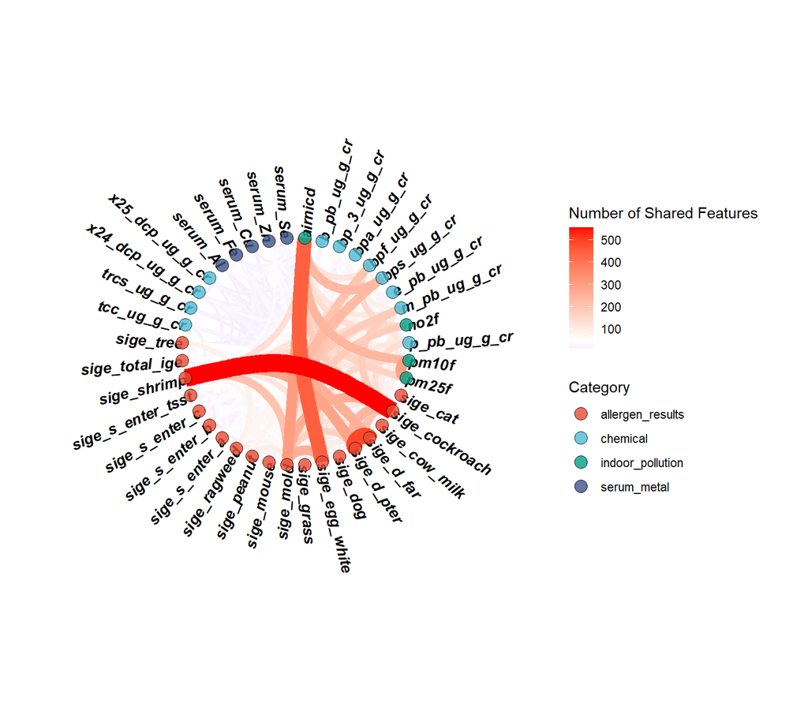

```r
# Plot Shared Feature Correlations Between Exposures
expom_multi |>
  plot_circos_exposure_shared_features(geneset = "degs")
```

# Enrichment Analysis

The benefit of grouping our exposures into categories is that we can perform enrichment analysis on the associated features to determine how broad categories of exposures are associated with features. The `run_enrichment` function is used to perform enrichment analysis. Here we use the `deg_exp_cor` geneset to perform enrichment on differentially abundant features correlated with exposures.

```r
# Perform Functional Enrichment Analysis
expom_enrich <- expom_multi |>
  run_enrichment(
    geneset = "deg_exp_cor",
    feature_col = "gene",
    mirna_assays = c("CD16+ Monocyte miRNA","CD4+ T-cell miRNA"),
    pval_threshold = 0.05,
    logfc_threshold = log2(1.5),
    action="add")
```

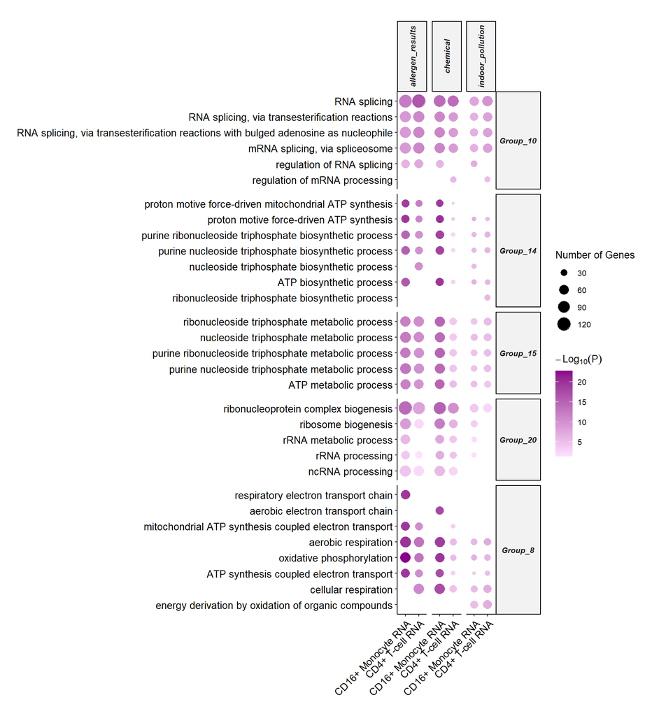

```r
# Plot functional enrichment results
expom_enrich |>
    plot_dotplot_enrichment(geneset = "deg_exp_cor")
```

```r
# Identify GO Groups that correlate with the outcome
expom_enrich <- expom_enrich |>
  associate_go_outcome(
    geneset = "deg_exp_cor",
    outcome = "fev_height",
    mirna_assays = c("CD4+ T-cell miRNA","CD16+ Monocyte miRNA"),
    covariates = c("age","sex","race"),
    action = "add"
  )
```

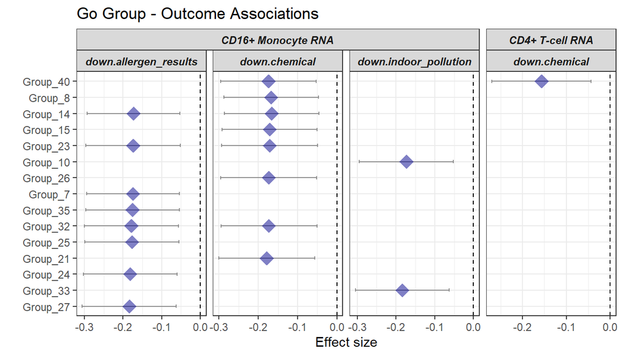

```r
# Plot GO Group Eigengene, Outcome Association
expom_enrich |>
  plot_associate_go_outcome(
    direction_filter = "down",
    filter_thresh = 0.2)
```

Here you’ll note that GO group 40, 14, 23, and 32 eigengenes are negatively associated our outcome variable of interest FEV1/height<sup>2</sup>, across multiple categories, meaning that variation in these GO groups is associated with worse lung function. You’ll also note that these groups appear to largely be driven by associations with allergens and chemicals in CD16+ Monocytes.We can now re-plot our dotplot to investigate what the biological functions associated with these GO groups.

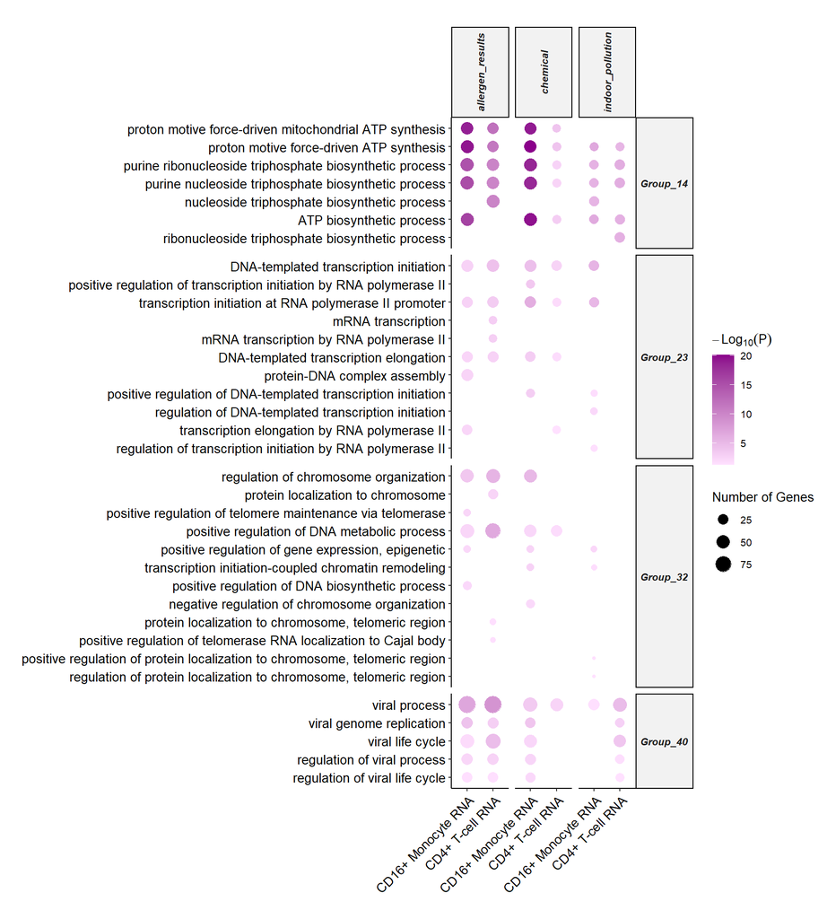

```r
# Plot GO Group Exposures
expom_enrich |>
  plot_dotplot_enrichment(
    geneset = "deg_exp_cor",
    go_groups = c("Group_40","Group_14","Group_23","Group_32"))
```

While some of the GO groups remain the same, we do see that groups associated with chromatin remodeling and telomere maintenance are now prioritized.

## References

1. Wild, C. P. Complementing the genome with an ‘exposome’: the outstanding challenge of environmental exposure measurement in molecular epidemiology. Cancer Epidemiol. Biomarkers Prev. 14, 1847–1850 (2005).
2. Chung, M. K. et al. Decoding the exposome: data science methodologies and implications in exposome-wide association studies (ExWASs). Exposome 4, osae001 (2024).